# Analysis of OMICS data, practical 7

Transcriptomics part 1

Eszter Ari

arieszter@ttk.elte.hu

Eötvös Loránd University, Budapest & Biological Research Centre, Szeged

March 27, 2026

## Omics…

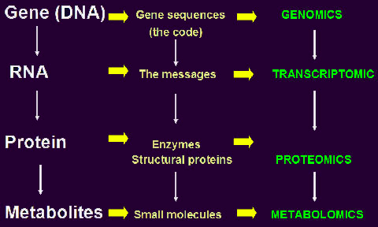

## Overview of the session

**Introduction**

- Definition
- History of transcription profiling
- RNA sequencing - NGS methods
- Advantages and disadvantages of RNA-seq

**RNA-seq data analysis**

- Quality checking, trimming
- Read mapping
- Read counting

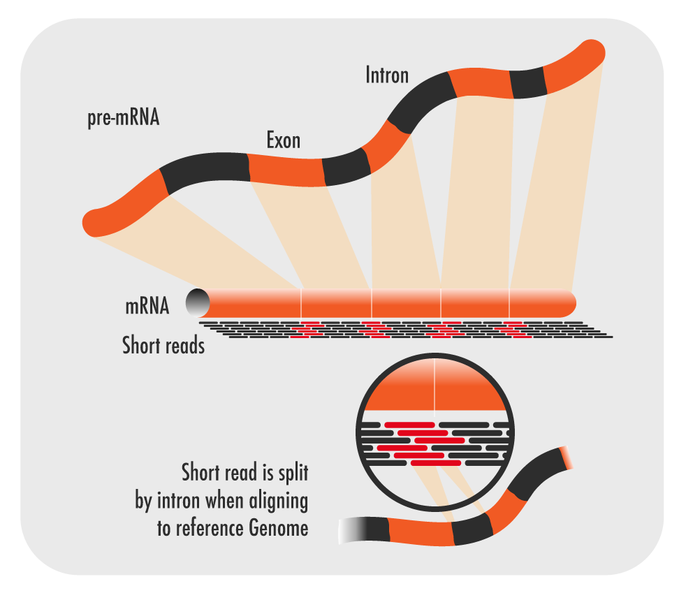

Technology Networks

# Introduction

## Transcriptomics

**Transcriptome**:

- the entire repertoire of transcripts in a species
- or cells, organs, individuals, populations, *etc*.
- at a specific time or under a specific set of conditions…
- represents a key link between information encoded in DNA and phenotype

**Types of different RNAs**:

- mRNA, rRNA, tRNA
- *Post-transcriptional modifiers*: small nuclear snRNA, small nucleolar snoRNA, …
- *RNA regulators*: micro miRNA, piwi-interacting piRNA, small interfering siRNA

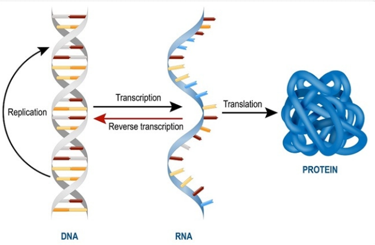

## Transcriptomics

- **Basis**: The amount of mRNA indicates the level of gene expression, and it correlates with the protein level.
- We can compare the gene expression of different cells, tissues, individuals, and populations.
- We can investigate the effects of different environments on gene expression.
- These help us to understand the underlying biological processes.

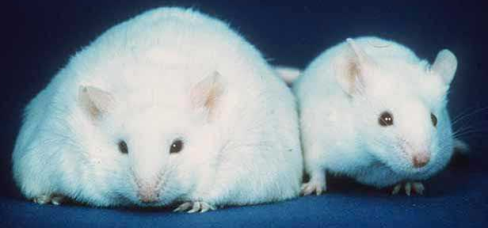

## Historical overview of expression profiling

Low-throughput RNA profiling methods:

- Northern blots (1977)
- reverse-transcription PCR (RT-PCR, 1992)
- quantitative real-time reverse transcription PCR (qRT-PCR)
- expressed sequence tags (ESTs)

High-throughput RNA profiling methods

- serial analysis of gene expression (SAGE) (1995)
- expression microarrays (1999)
- RNA-seq: massively parallel sequencing of RNA (cDNA) molecules (2008)

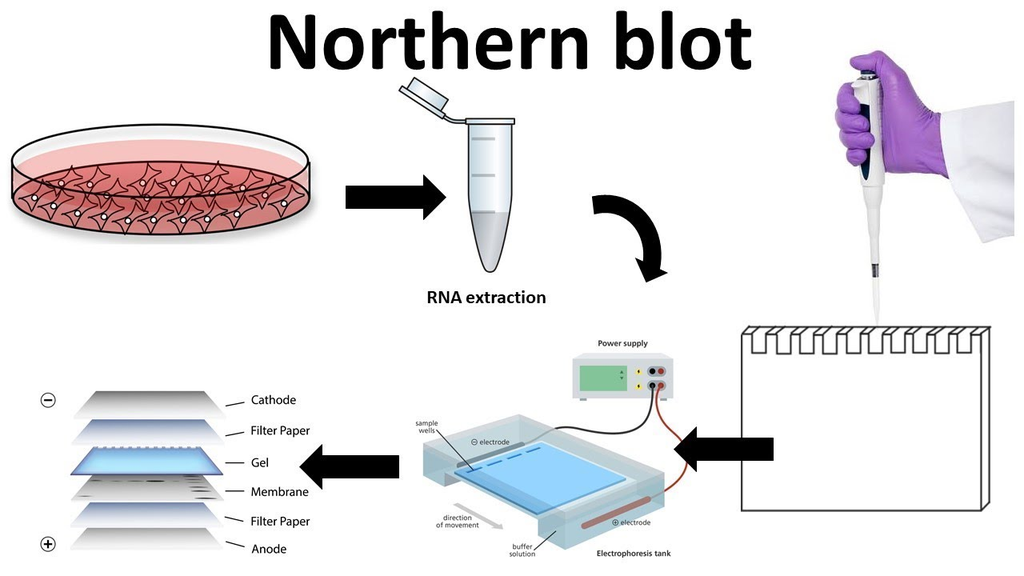

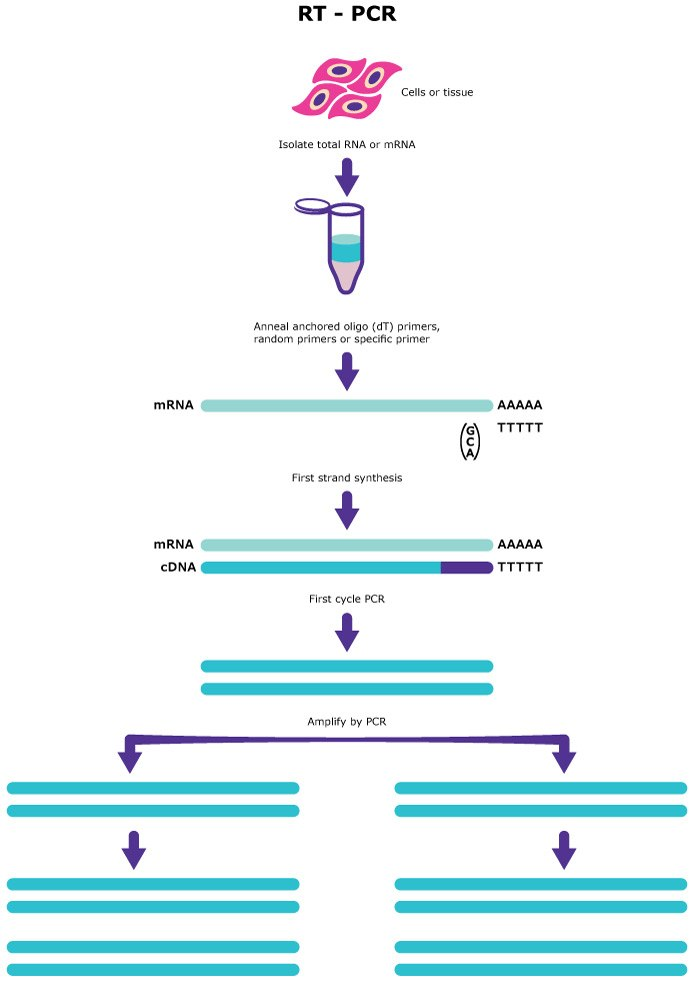

[figure not shown]

Malone JH & Oliver B (2011) Microarrays, deep sequencing and the true measure of the transcriptome. *BMC Biol* **9:**34

## How does RNA-Seq work?

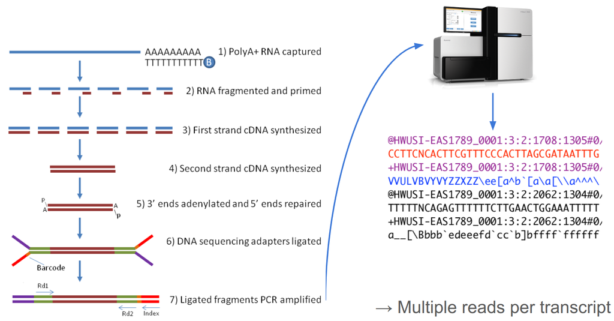

® Henrik Lantz: RNA sequencing, transcriptome and expression quantification

## Simplistic overview

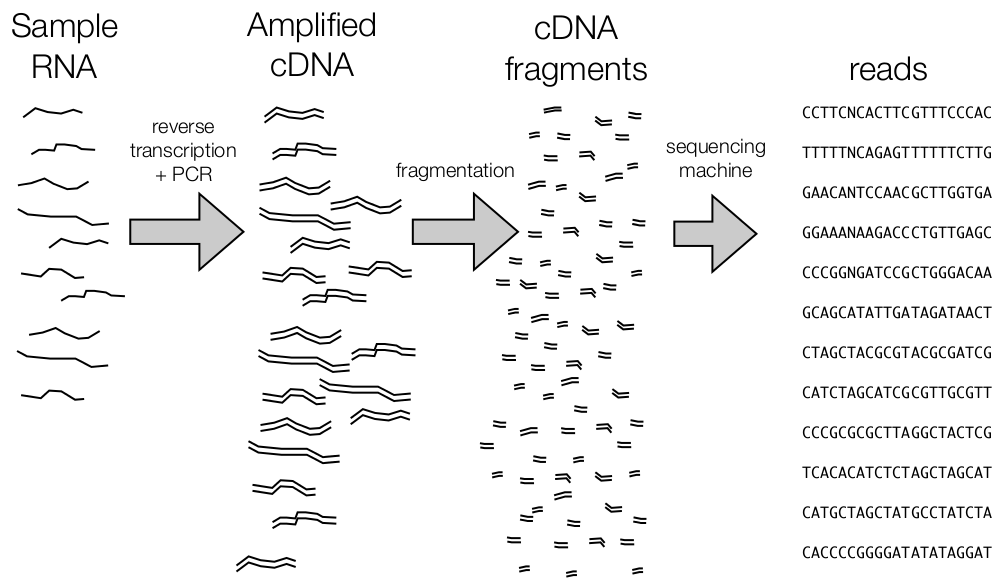

## Advantages of RNA-seq

- Robustness, high reproducibility
- High sensitivity
- “Direct” measurement of gene expression at the mRNA level → absolute(?) abundance of a transcript
- The **sequences** of transcribed RNAs can be **reconstructed**
- All transcripts – even “novel” ones – can be detected
- Detecting transcript **isoformes** and **splicing junctions**
  - → study alternative splicing, exact start - end sites
  - → updating genome annotation
- Detecting **polymorphisms** (SNPs)
  - → study allele-specific expression
- Can be used on species for which a full genome sequence is not available

[figure not shown]

## Limitations of RNA-seq

- RNA-seq is a bit more **costly** than microarrays
  - RNA-seq: more **extensive bioinformatic analysis** and great computers are required
- Cannot detect **post-transcriptional modifications**
- Nor **post-transcriptional regulation**:
  - the amount of mRNA transcribed from geneX is not necessarily equal to the amount of proteinX
  - regulation: miRNA …
- **Biases**: library size, fragment length, GC content, hexamer priming…
  - → normalization

[figure not shown]

# Bioinformatic workflow

## Work-flow of RNA-seq data analysis

0. Extract expressed RNA, sequencing → fastq file
1. Pre-mapping quality checking, trimming (filtering)
2. Read mapping to the reference genome **OR** *de novo* assembly of transcripts
   - Post mapping quality checking
3. Read counting
4. Quantitative Analyses: comparing expression levels
5. Functional enrichment analysis: GO, pathways…

# 2. Read mapping to reference genome

## Mapping

Align reads to the genome

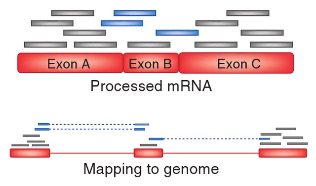

Trapnell C & Salzberg S (2009) How to map billions of short reads onto genomes. *Nat Biotechnol* 27, 455

## Specific mappers for RNA-seq

A standard DNA mapper will not map reads spanning two exons or splice junctions.

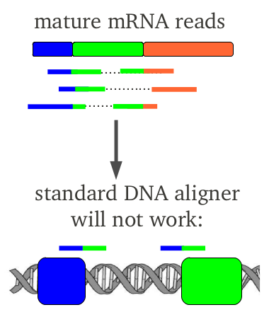

©Irina Pulyakhina

## The RNA-seq mapper

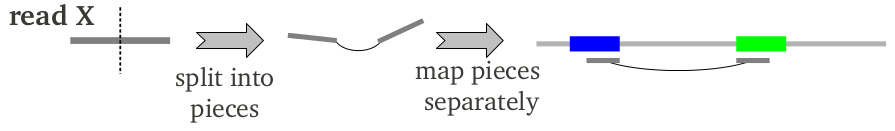

©Irina Pulyakhina

## Mapping to genome *vs.* to transcriptome

- Genome:
  - complete information (?)
- Transcriptome assembly:
  - is it complete?
  - problem of multiple mappings to alternative isoforms
- From **the same individual** OR **reference genome** of the species?
  - → the reads will not be 100% identical to the reference

## Mapping the reads to the reference genome

- Reference genome:
  - sequence in FASTA file → for mapping
  - (annotation in GTF file → for counting)
- Mapper software: `GSNAP`, `STAR`, `TopHat2`, `Rsubread`, *etc.*
  - indexing the genome
  - mapping the reads to the genome → can be computationally intense
- Filtering reads
  - both pairs mapped to the same chromosome?
- Sorting reads
  - by read coordinates **OR**
  - by read names → depending on the next software in the pipeline

## Different properties of RNA-Seq mappers

- alignment algorithm
- producing unique / non-unique mappings
- using the canonical / non-canonical splice sites
- using annotation of known exons OR not
- programming language, platform, interface
- speed, memory requirement, multi-threading possibility

be aware: errors may occur!

## Difficulties can occur during mapping

- **pseudogenes**: the reads were mapped to something that didn’t express
- **repetitive regions**: the reads were mapped to multiple locations
- reads mapped to **intronic and intergenic regions** → how should we treat them?
- identification and quantification of **alternative transcripts**
- distinguish between (allele-specific) **SNPs** and sequencing errors

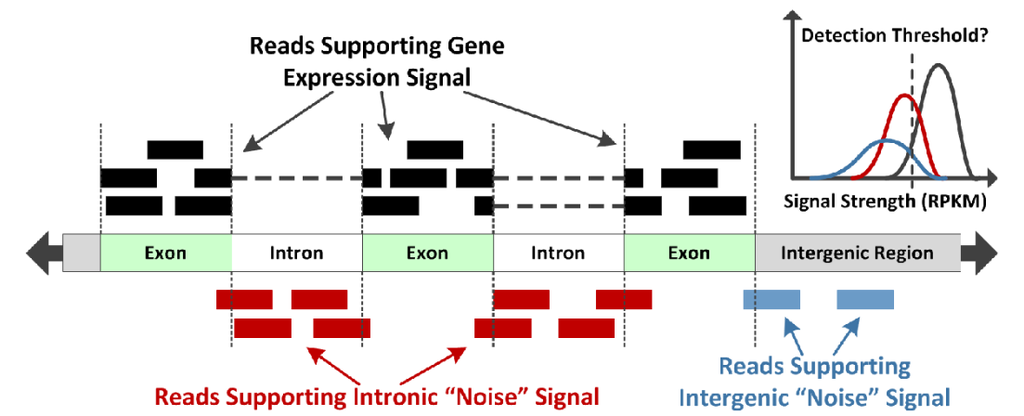

Harati S *et al.* (2014) Investigation of factors affecting RNA-seq gene expression calls. 36th Annual International Conference of IEEE EMBS: 5232

## SAM/BAM file

| Col | Field | Type | Brief description |
| --- | --- | --- | --- |
| 1 | QNAME | String | Query template NAME |
| 2 | FLAG | Int | bitwise FLAG |
| 3 | RNAME | String | References sequence NAME |
| 4 | POS | Int | 1- based leftmost mapping POSition |
| 5 | MAPQ | Int | MAPping Quality |
| 6 | CIGAR | String | CIGAR string |
| 7 | RNEXT | String | Ref. name of the mate/next read |
| 8 | PNEXT | Int | Position of the mate/next read |
| 9 | TLEN | Int | observed Template LENgth |
| 10 | SEQ | String | segment SEQuence |
| 11 | QUAL | String | ASCII of Phred-scaled base QUALity+33 |

## SAM/BAM file

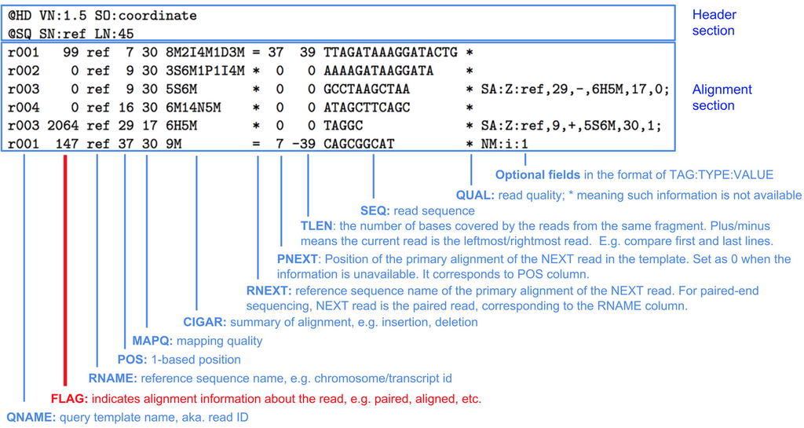

https://www.samformat.info/sam-format-flag

## FLAG

| # | Decimal | Description of read |
| --- | --- | --- |
| 1 | 1 | Read paired |
| 2 | 2 | Read mapped in proper pair |
| 3 | 4 | Read unmapped |
| 4 | 8 | Mate unmapped |
| 5 | 16 | Read reverse strand |
| 6 | 32 | Mate reverse strand |
| 7 | 64 | First in pair |
| 8 | 128 | Second in pair |
| 9 | 256 | Not primary alignment |
| 10 | 512 | Read fails platform/vendor quality checks |
| 11 | 1024 | Read is PCR or optical duplicate |
| 12 | 2048 | Supplementary alignment |

## CIGAR (Concise Idiosyncratic Gapped Alignment Report) codes

- A compressed representation of an alignment
- Made up of pairs, *e.g.* 76H130M
  - Here, “op” is an operation specified as a single character, usually an upper-case letter, codes:
    - match (M), mismatch (X)
    - insertion (I), deletion (D)
    - soft clipping (S), hard clipping (H)
    - two identical letters (=)
  - The “integer” specifies a number of consecutive operations.

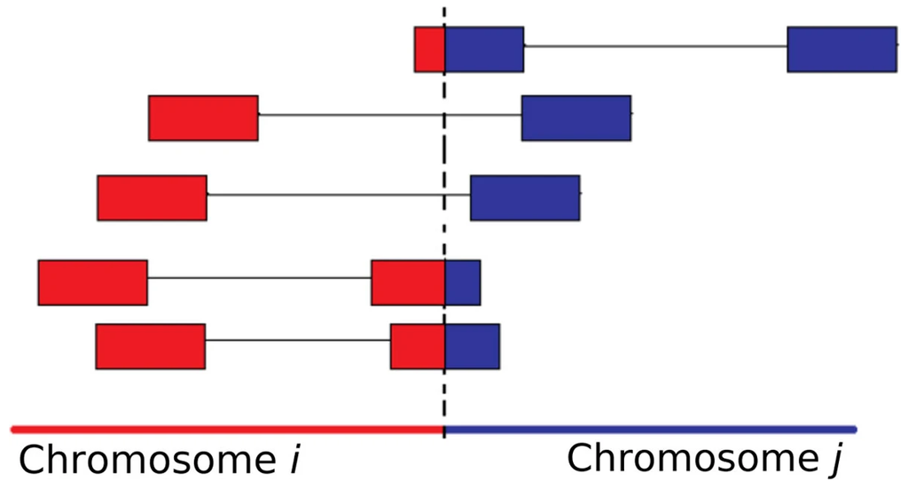

Hayes M & Li J (2013) [Bellerophon: a hybrid method for detecting interchromosomal rearrangements at base pair resolution using next-generation sequencing data.](https://doi.org/10.1186/1471-2105-14-S5-S6) *BMC Bioinfo* **14**: (Suppl 5), S6

## Post-mapping QC

- % of uniquely mapped reads (unambiguous)
- % of reads mapped to multiple locations (ambiguous)
  - What to do with ambiguous reads?
- % of soft or hard clipped reads
  - How to treat them?
- % of unmapped reads: higher compared to the genomic mapping, because of splicing effects

[figure not shown]

# 3. Read counting

## Read counting

Find reads that map to the coding sequence

- count read(pairs) per gene, exon, transcript
- → count table
- CPM, RPKM, FPKM

Genome annotation: GTF (GFF, SAF, …) file:

- contains the location of exons, genes, and other transcripts

## Read counting

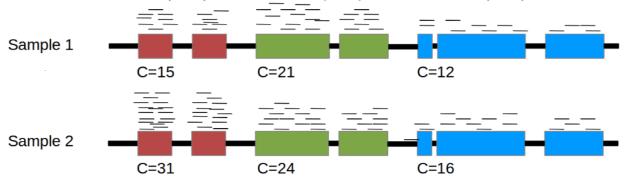

## Complexity of transcription

[figure not shown]

## We have to decide before counting

- Exclude or include reads, read-pair mapped to exons partially?
  - What does “partially” mean? %
- Exclude or include reads, read-pairs mapped to introns?
  - depending on the reliability of the genome annotation

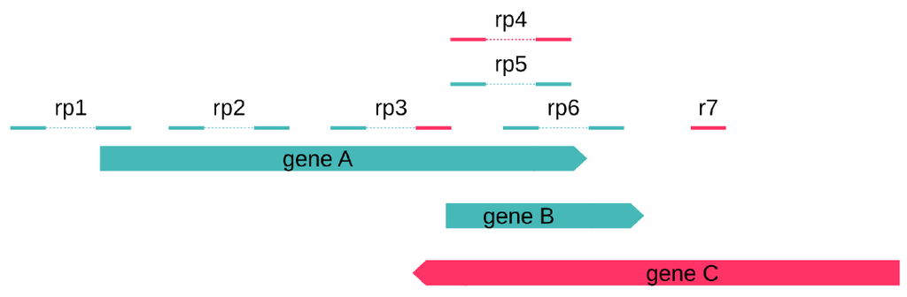

https://code.google.com/p/recog/

## Count table with raw counts

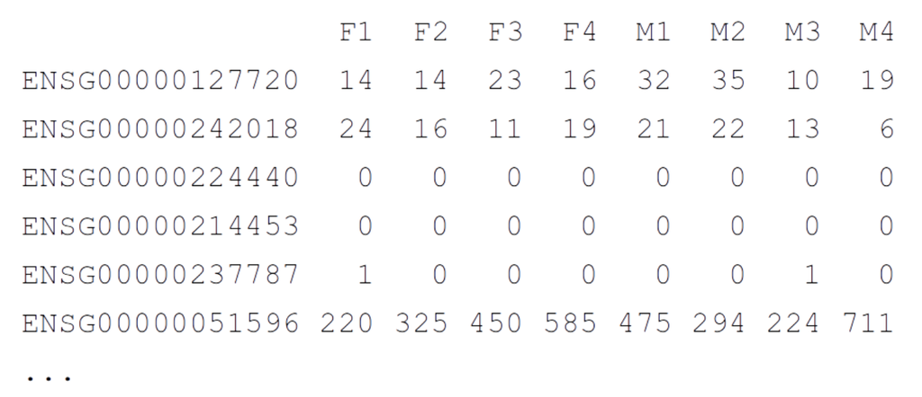

## Recommended webpages and papers

- StatQuest video: [A gentle introduction to RNA-seq](https://www.youtube.com/watch?v=tlf6wYJrwKY)
- [RNA-Seq blog](http://www.rna-seqblog.com/)
- [RNA-seqlopedia](http://rnaseq.uoregon.edu/)
- De Wit P, Pespeni MH, Ladner JT, et al. (2012) [The simple fool’s guide to population genomics via RNA-Seq: an introduction to high-throughput sequencing data analysis.](https://doi.org/10.1111/1755-0998.12003) *Mol Ecol Resour* **12**, 1058
- Malone JH & Oliver B (2011) [Microarrays, deep sequencing and the true measure of the transcriptome.](https://doi.org/10.1186/1741-7007-9-34) *BMC Biol* **9**, 34
- Oshlack A, Robinson MD & Young MD (2010) [From RNA-seq reads to differential expression results.](https://doi.org/10.1186/gb-2010-11-12-220) *Genome Biol* **11**, 220
- Anders S *et al.* (2013) [Count-based differential expression analysis of RNA sequencing data using R and Bioconductor.](https://doi.org/10.1038/nprot.2013.099) *Nat Protoc* **8**, 1765

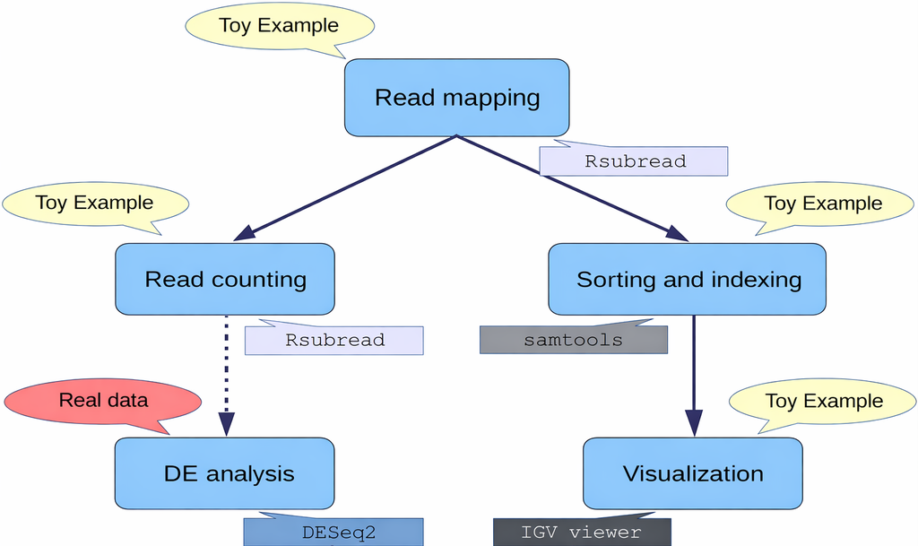